# time-series seed behavior

Miranda Melen

May 2023

#Libraries

```r
#install.packages("dplyr")
#install.packages("ggplot2")
#install.packages("tidyr")
#install.packages("stringr")
#install.packages("scales")
library(dplyr)
library(ggplot2)
library(tidyr)
library(stringr)
library(scales)
library(survival)
library(coxme)
```

```r
mydata<-read.csv("/Users/Miranda/Documents/Education/UC Santa Cruz/Dittrichia/Dittrichia_Analysis/data/seed_behavior/cox_germ_soil8-2-21.csv",stringsAsFactors=T)
mydata$DishNum<-as.factor(mydata$DishNum)
str(mydata) #Check that each column has the right class (factor, integer, numeric, etc.)
```

```
'data.frame':   1600 obs. of  21 variables:
 $ Num         : int  1 2 3 4 5 6 7 8 9 10 ...
 $ Site        : Factor w/ 8 levels "BAY","CHE","GUA",..: 1 1 1 1 1 1 1 1 1 1 ...
 $ Habitat     : Factor w/ 2 levels "Roadside","Vegetated": 2 2 2 2 2 2 2 2 2 2 ...
 $ Population  : Factor w/ 16 levels "BAY-R","BAY-V",..: 2 2 2 2 2 2 2 2 2 2 ...
 $ Rep         : Factor w/ 5 levels "A","B","C","D",..: 1 1 1 1 1 1 1 1 1 1 ...
 $ DishNum     : Factor w/ 160 levels "1","2","3","4",..: 1 1 1 1 1 1 1 1 1 1 ...
 $ PopNum      : int  1 1 1 1 1 1 1 1 1 1 ...
 $ Treatment   : Factor w/ 2 levels "Construction Soil",..: 2 2 2 2 2 2 2 2 2 2 ...
 $ ID          : Factor w/ 160 levels "A_1_Construction",..: 2 2 2 2 2 2 2 2 2 2 ...
 $ SurvivalID  : Factor w/ 4 levels "Construction_A",..: 3 3 3 3 3 3 3 3 3 3 ...
 $ NoGermDish  : int  1 1 1 1 1 1 1 1 1 1 ...
 $ TotGermDish : int  9 9 9 9 9 9 9 9 9 9 ...
 $ PropGermDish: num  0.9 0.9 0.9 0.9 0.9 0.9 0.9 0.9 0.9 0.9 ...
 $ PlotPropGerm: num  0.1 0.1 0.1 0.1 0.1 0.1 0.1 0.1 0.1 0.1 ...
 $ Label       : Factor w/ 10 levels "Seed10Date","Seed1Date",..: 2 3 4 5 6 7 8 9 10 1 ...
 $ PlantDate   : Factor w/ 1 level "7/21/21": 1 1 1 1 1 1 1 1 1 1 ...
 $ GermDate    : Factor w/ 12 levels "","7/23/21","7/24/21",..: 2 2 2 5 6 6 6 8 8 1 ...
 $ Censor      : int  1 1 1 1 1 1 1 1 1 NA ...
 $ Census      : Factor w/ 1 level "8/3/21": 1 1 1 1 1 1 1 1 1 1 ...
 $ DaysCensus  : int  13 13 13 13 13 13 13 13 13 13 ...
 $ DaysToGerm  : int  2 2 2 5 6 6 6 8 8 0 ...
```

```r
myFPdata<-read.csv("/Users/Miranda/Documents/Education/UC Santa Cruz/Dittrichia/Dittrichia_Analysis/data/seed_behavior/cox_germ_filter_paper8-2-21.csv",stringsAsFactors=T)
myFPdata$DishNum<-as.factor(myFPdata$DishNum)
str(myFPdata) #Check that each column has the right class (factor, integer, numeric, etc.)
```

```
'data.frame':   800 obs. of  20 variables:
 $ Num         : int  1 2 3 4 5 6 7 8 9 10 ...
 $ Site        : Factor w/ 8 levels "BAY","CHE","GUA",..: 1 1 1 1 1 1 1 1 1 1 ...
 $ Habitat     : Factor w/ 2 levels "Roadside","Vegetated": 2 2 2 2 2 2 2 2 2 2 ...
 $ Population  : Factor w/ 16 levels "BAY-O","BAY-R",..: 1 1 1 1 1 1 1 1 1 1 ...
 $ Rep         : Factor w/ 5 levels "A","B","C","D",..: 1 1 1 1 1 1 1 1 1 1 ...
 $ DishNum     : Factor w/ 80 levels "1","2","3","4",..: 1 1 1 1 1 1 1 1 1 1 ...
 $ PopNum      : int  1 1 1 1 1 1 1 1 1 1 ...
 $ Treatment   : Factor w/ 1 level "Filter": 1 1 1 1 1 1 1 1 1 1 ...
 $ ID          : Factor w/ 80 levels "A_01","A_02",..: 1 1 1 1 1 1 1 1 1 1 ...
 $ SurvivalID  : Factor w/ 5 levels "Filter_A","Filter_B",..: 1 1 1 1 1 1 1 1 1 1 ...
 $ NoGermDish  : int  4 4 4 4 4 4 4 4 4 4 ...
 $ TotGermDish : int  6 6 6 6 6 6 6 6 6 6 ...
 $ PropGermDish: num  0.6 0.6 0.6 0.6 0.6 0.6 0.6 0.6 0.6 0.6 ...
 $ Label       : Factor w/ 10 levels "Seed10Date","Seed1Date",..: 2 3 4 5 6 7 8 9 10 1 ...
 $ PlantDate   : Factor w/ 1 level "7/9/21": 1 1 1 1 1 1 1 1 1 1 ...
 $ GermDate    : Factor w/ 23 levels "","7/10/21","7/11/21",..: 3 3 3 4 4 6 14 21 1 1 ...
 $ Censor      : int  1 1 1 1 1 1 1 1 NA NA ...
 $ Census      : Factor w/ 1 level "8/2/21": 1 1 1 1 1 1 1 1 1 1 ...
 $ DaysCensus  : int  0 0 0 0 0 0 0 0 0 0 ...
 $ DaysToGerm  : int  2 2 2 3 3 5 13 20 0 0 ...
```

#Histograms

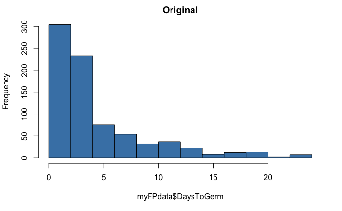

```r
#All data
hist(myFPdata$DaysToGerm,col='steelblue',main='Original')
```

#Cox Model Start by making a simple model with no random effects. This will be compared to the full model with random effects. ##Simple Model

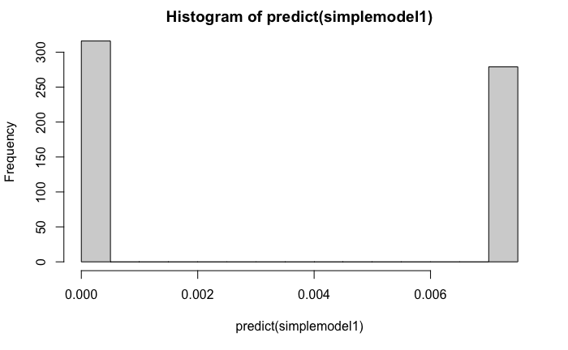

```r
simplemodel1<-coxph(Surv(DaysToGerm,
                         Censor)~
                      Habitat,
                    data=myFPdata)
#summary(simplemodel1)
#print(simplemodel1)
#predict(simplemodel1)
hist(predict(simplemodel1))
```

##Full Model 1 - coxme Now make a full model using random effects

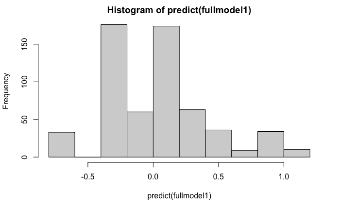

```r
fullmodel1<-coxme(Surv(DaysToGerm,
                       Censor)~
                    Habitat
                    +(1|Site/Population/DishNum),
                  data=myFPdata)
#summary(fullmodel1)
#print(fullmodel1)
#predict(fullmodel1)
hist(predict(fullmodel1))
```

Now we can compare the models to see which model is best

```r
anova(simplemodel1,fullmodel1) #There is a significance between models
```

```
Analysis of Deviance Table
 Cox model: response is  Surv(DaysToGerm, Censor)
 Model 1: ~Habitat
 Model 2: ~Habitat + (1 | Site/Population/DishNum)
   loglik  Chisq Df P(>|Chi|)
1 -3210.3
2 -3179.9 60.897  3  3.78e-13 ***
---
Signif. codes:  0 ‘***’ 0.001 ‘**’ 0.01 ‘*’ 0.05 ‘.’ 0.1 ‘ ’ 1
```

```r
AIC(simplemodel1,fullmodel1) #But comparing the AIC scores is easiest. Keep the lower AIC score because that is considered the better model. The full model (fullmodel1) is best
```

|  | df | AIC |
| --- | --- | --- |
| simplemodel1 | 1.00000 | 6422.607 |
| fullmodel1 | 21.51901 | 6341.756 |

##Best Model

```r
fullmodel1
```

```
Cox mixed-effects model fit by maximum likelihood
  Data: myFPdata
  events, n = 595, 595 (205 observations deleted due to missingness)
  Iterations= 16 69
                    NULL Integrated    Fitted
Log-likelihood -3210.307  -3179.855 -3149.359

                  Chisq    df          p   AIC    BIC
Integrated loglik  60.9  4.00 1.8725e-12 52.90  35.35
 Penalized loglik 121.9 21.52 5.5511e-16 78.86 -15.58

Model:  Surv(DaysToGerm, Censor) ~ Habitat + (1 | Site/Population/DishNum)
Fixed coefficients
                         coef exp(coef)  se(coef)     z    p
HabitatVegetated -0.008711603 0.9913262 0.2197205 -0.04 0.97

Random effects
 Group                   Variable    Std Dev    Variance
 Site/Population/DishNum (Intercept) 0.14656697 0.02148188
 Site/Population         (Intercept) 0.40048617 0.16038918
 Site                    (Intercept) 0.14285066 0.02040631
```

###Risk Assessment These values are found in the model summary, but if you want to pull them out, here is how you interpret them.

```r
#1 = no effect, <1 = decreased risk of death, >1 = increased risk of death.

exp(coef(fullmodel1)) #When we run this, vegetated is just below 1, which means that vegetated has an ever so slight decrease in germination compared to roadside.
```

```
HabitatVegetated
       0.9913262
```

```r
#Here we pull the std dev of the random effects which works like the fixed effect coefficients to calculate risk.
exp(ranef(fullmodel1)$Site) # Pretty even among all the sites
```

```
      BAY       CHE       GUA       LEX       OAP       PAR       PEN       SSJ
1.1054084 0.9033639 0.9799643 1.0438625 0.9892786 1.0012048 1.0299980 0.9595841
```

#ggplots ##Filter Paper: Proportion Germinated x Time with Habitat and Treatment (data pooled by dish)

```r
myFPdata1<-myFPdata%>%
  filter(DaysToGerm!=0)%>% #our real data has some zeros because some seeds didn't germinate, but we need those to be removed since they are not real zeros
  mutate(type=c("real")) #here we add a column identifies our real

germ_rate2.0<-myFPdata1%>%
  group_by(DishNum,GermDate,Habitat,Treatment,DaysToGerm)%>%
  summarize(NumGerm=n(),PropGerm=NumGerm/10)%>%
  mutate(PlotTreatment=paste(Habitat,Treatment,sep="/"))%>% #create a new column called PlotTreatment combining Habitat and Treatment with a / to separate
  group_by(DishNum)%>%
  mutate(CumPropGerm=cumsum(PropGerm))
#make empty data frame to fill with closest or actual number
germ_rate2.1<-data.frame(PlotTreatment="blank",
                      DaysToGerm=c(rep(seq(1,12,1),80)), #why was this 40? doesn't seem to do anything
                      DishNum=rep(seq(1,80,1),each=12), #changed from 1,160,1 to 1,80,1 because now I only have 80 dishes (10 seeds each, total 800 seeds)
                      PropGerm=0,CumPropGerm=0)

#germ_rate2.1<-
germ_rate2.1%>% #is this assignment necessary?
  filter(germ_rate2.1$DishNum%in%germ_rate2.0$DishNum) #actually prefilter dish numbers by comparing germ_rate2.0 and germ_rate2.1 and only keeping the rows that match by DishNum
```

| PlotTreatment | DaysToGerm | DishNum | PropGerm | CumPropGerm |
| --- | --- | --- | --- | --- |
| blank | 1 | 1 | 0 | 0 |
| blank | 2 | 1 | 0 | 0 |
| blank | 3 | 1 | 0 | 0 |
| blank | 4 | 1 | 0 | 0 |
| blank | 5 | 1 | 0 | 0 |
| blank | 6 | 1 | 0 | 0 |
| blank | 7 | 1 | 0 | 0 |
| blank | 8 | 1 | 0 | 0 |
| blank | 9 | 1 | 0 | 0 |
| blank | 10 | 1 | 0 | 0 |

[output cut: 950 more lines]

```r
#for loop to fill in missing data, may take a bit, warnings are just about making empty data frame
for (i in 1:nrow(germ_rate2.1)){
  #first check if the dish number is in the data set
  if(germ_rate2.1$DishNum[i]%in%germ_rate2.0$DishNum){
    #make temporary data frame of the data set of dish
    temp<-germ_rate2.0%>%
      filter(DishNum==germ_rate2.1$DishNum[i])%>%#first filter for the right dish
      mutate(diff=DaysToGerm-as.numeric(germ_rate2.1$DaysToGerm[i]))
    #now filter for specific day
    filltemp<-temp%>% #subtract day
      filter(diff<=0)%>% #filter for either earlier or same day
      filter(diff==max(diff))#filter for exact match or closest
    if(nrow(filltemp)>0){#check if it is empty data frame, meaning no close day
      germ_rate2.1[i,]<-c(filltemp$PlotTreatment,germ_rate2.1$DaysToGerm[i],germ_rate2.1$DishNum[i],filltemp$PropGerm,filltemp$CumPropGerm)
    }else{
    germ_rate2.1[i,]<-c(temp$PlotTreatment[1],germ_rate2.1$DaysToGerm[i],germ_rate2.1$DishNum[i],0,0)
  }}
  else{#if there is no data for the dish just skip.
    next
  }
}
```

[output not shown]

[output cut: 288 more lines]

[output not shown]

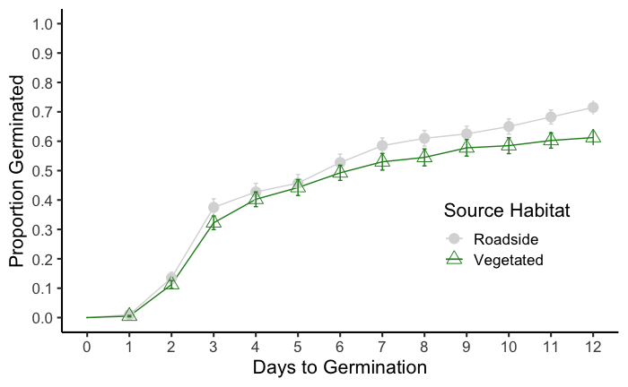

```r
#we want the graph to start at zero, but the data starts on day 2, so here we create fake data for the line to use
fakedataFP<-data.frame(PlotTreatment=c("Roadside/Filter","Vegetated/Filter"),
                      DaysToGerm=c(0),
                      DishNum=c(0),
                      PropGerm=c(0),
                      CumPropGerm=c(0),
                      type=c("fake"))

fakedataFP$DaysToGerm<-as.character(fakedataFP$DaysToGerm)
fakedataFP$DishNum<-as.character(fakedataFP$DishNum)
fakedataFP$PropGerm<-as.character(fakedataFP$PropGerm)
fakedataFP$CumPropGerm<-as.character(fakedataFP$CumPropGerm)
fakedataFP$type<-as.character(fakedataFP$type)
germ_rate2.1$DaysToGerm<-as.character(germ_rate2.1$DaysToGerm)
germ_rate2.1$DishNum<-as.character(germ_rate2.1$DishNum)
germ_rate2.1$PropGerm<-as.character(germ_rate2.1$PropGerm)
germ_rate2.1$CumPropGerm<-as.character(germ_rate2.1$CumPropGerm)

#put real data and fake data together
germ_rate2.2<-germ_rate2.1%>%
  mutate(type=c("real"))%>% #here we add a column to identify our real data
  bind_rows(fakedataFP) #now we add our fake data so that we have one dataframe with real and fake data (labeled, of course)

germ_rate2.2$CumPropGerm<-as.numeric(germ_rate2.2$CumPropGerm)

germ_rate2.2<-germ_rate2.2%>%
  group_by(type,DaysToGerm,PlotTreatment)%>%
  summarize(mean_CumPropGerm=mean(CumPropGerm,
                               na.rm=TRUE),
            sd_prop=sd(CumPropGerm,na.rm=TRUE),
            se_prop=sd_prop/sqrt(80))%>% #I'm not sure this 40 makes sense for calculating SE so its changed to 80 sample size
  mutate(DaysToGerm=as.numeric(DaysToGerm))
germ_rate2.2_gg<-ggplot(germ_rate2.2, #making a graph with ggplot
                      aes(x=DaysToGerm, #variable for x-axis
                          y=mean_CumPropGerm, #variable for y-axis
                          color=PlotTreatment, #how colors should be assigned
                          shape=PlotTreatment))+ #how shapes should be assigned
  geom_line(linewidth=0.5)+ #now we make the line
  geom_point(aes(size=type))+ #now we add the data points
  geom_errorbar(aes(ymin=mean_CumPropGerm-se_prop,
                    ymax=mean_CumPropGerm+se_prop),
                width=0.2,
                size=0.5,
  #              color="gray58",
                position=position_dodge(width=0.0,))+
  theme_bw(base_size=16)+ #theme and base_size is the font size for labels
  theme(panel.border=element_blank(),
        panel.grid.major=element_blank(),
        panel.grid.minor=element_blank(),
        axis.line=element_line(colour="black"),
        legend.position = c(0.8, 0.3))+ #position of our legend
  scale_y_continuous(name="Proportion Germinated", #y-axis: title
                     limits=c(0,1), #y-axis: range
                     breaks=c(0.0,0.1,0.2,0.3,0.4,0.5,0.6,0.7,0.8,0.9,1.0))+ #y-axis: manual incremental breaks
  scale_x_continuous(name="Days to Germination", #x-axis: title
                     limits=c(0,12), #x-axis: range
                     breaks=seq(0,12,1))+ #x-axis: incremental breaks by giving range and requesting a sequence by 1
  scale_size_manual(values=c(0,4), #second number controls the size of the point
                    guide="none")+
  scale_color_manual(values=c("gray85","forestgreen"),
                    labels=c("Roadside","Vegetated"))+ #colors assigned in order of the legend
#  scale_shape_manual(values=c(19,17,19),
  scale_shape_manual(values=c(16,2),
                    labels=c("Roadside","Vegetated"))+
    labs(y="Proportion Germinated",
       fill="Source Habitat",
       color="Source Habitat",
       shape="Source Habitat")+
  guides(colour=guide_legend(override.aes=list(size=4)),
         shape=guide_legend(override.aes=list(size=4)))
germ_rate2.2_gg

ggsave(plot=germ_rate2.2_gg,file="/Users/Miranda/Documents/Education/UC Santa Cruz/Dittrichia/Dittrichia_Analysis/figures/germ_rate2.2_gg.png",width=25,height=15,units="cm",dpi=800)
```

##Soil Data: Proportion Germinated x Time with Habitat and Treatment (data pooled by dish)

```r
mydata1<-mydata%>%
  filter(DaysToGerm!=0)%>% #our real data has some zeros because some seeds didn't germinate, but we need those to be removed since they are not real zeros
  mutate(type=c("real")) #here we add a column identifies our real

germ_rate1.0<-mydata1%>%
  group_by(DishNum,GermDate,Habitat,Treatment,DaysToGerm)%>%
  summarize(NumGerm=n(),PropGerm=NumGerm/10)%>%
  mutate(PlotTreatment=paste(Habitat,Treatment,sep="/"))%>% #create a new column called PlotTreatment combining Habitat and Treatment with a / to separate
  group_by(DishNum)%>%
  mutate(CumPropGerm=cumsum(PropGerm))

#make empty data frame to fill with closest or actual number
germ_rate1.1<-data.frame(PlotTreatment="blank",
                      DaysToGerm=c(rep(seq(1,12,1),40)),
                      DishNum=rep(seq(1,160,1),each=12),
                      PropGerm=0,CumPropGerm=0)

germ_rate1.1<-germ_rate1.1%>%
  filter(germ_rate1.1$DishNum%in%germ_rate1.0$DishNum) #actually prefilter dish numbers

#for loop to fill in missing data, may take a bit, warnings are just about making empty data frame
for (i in 1:nrow(germ_rate1.1)){
  #first check if the dish number is in the data set
  if(germ_rate1.1$DishNum[i]%in%germ_rate1.0$DishNum){
    #make temporary data frame of the data set of dish
    temp<-germ_rate1.0%>%
      filter(DishNum==germ_rate1.1$DishNum[i])%>%#first filter for the right dish
      mutate(diff=DaysToGerm-as.numeric(germ_rate1.1$DaysToGerm[i]))
    #now filter for specific day
    filltemp<-temp%>% #subtract day
      filter(diff<=0)%>% #filter for either earlier or same day
      filter(diff==max(diff))#filter for exact match or closest
    if(nrow(filltemp)>0){#check if it is empty data frame, meaning no close day
      germ_rate1.1[i,]<-c(filltemp$PlotTreatment,germ_rate1.1$DaysToGerm[i],germ_rate1.1$DishNum[i],filltemp$PropGerm,filltemp$CumPropGerm)
    }else{
    germ_rate1.1[i,]<-c(temp$PlotTreatment[1],germ_rate1.1$DaysToGerm[i],germ_rate1.1$DishNum[i],0,0)
  }}
  else{#if there is no data for the dish just skip.
    next
  }
}

#we want the graph to start at zero, but the data starts on day 2, so here we create fake data for the line to use
fakedata1<-data.frame(PlotTreatment=c("Roadside/Construction Soil","Roadside/Field Soil","Vegetated/Construction Soil","Vegetated/Field Soil"),
                      DaysToGerm=c(0),
                      DishNum=c(0),
                      PropGerm=c(0),
                      CumPropGerm=c(0),
                      type=c("fake"))

fakedata1$DaysToGerm<-as.character(fakedata1$DaysToGerm)
fakedata1$DishNum<-as.character(fakedata1$DishNum)
fakedata1$PropGerm<-as.character(fakedata1$PropGerm)
fakedata1$CumPropGerm<-as.character(fakedata1$CumPropGerm)
fakedata1$type<-as.character(fakedata1$type)

#put real data and fake data together
germ_rate1.2<-germ_rate1.1%>%
  mutate(type=c("real"))%>% #here we add a column to identify our real data
  bind_rows(fakedata1) #now we add our fake data so that we have one dataframe with real and fake data (labeled, of course)

germ_rate1.2$CumPropGerm<-as.numeric(germ_rate1.2$CumPropGerm)

germ_rate1.2<-germ_rate1.2%>%
  group_by(type,DaysToGerm,PlotTreatment)%>%
  summarize(mean_CumPropGerm=mean(CumPropGerm,
                               na.rm=TRUE),
            sd_prop=sd(CumPropGerm,na.rm=TRUE),
            se_prop=sd_prop/sqrt(40))%>%
  mutate(DaysToGerm=as.numeric(DaysToGerm))

germ_rate1.2_gg<-ggplot(germ_rate1.2, #making a graph with ggplot
                      aes(x=DaysToGerm, #variable for x-axis
                          y=mean_CumPropGerm, #variable for y-axis
                          color=PlotTreatment, #how colors should be assigned
                          shape=PlotTreatment))+ #how shapes should be assigned
  geom_line(linewidth=0.5)+ #now we make the line
  geom_point(aes(size=type))+ #now we add the data points
  geom_errorbar(aes(ymin=mean_CumPropGerm-se_prop,
                    ymax=mean_CumPropGerm+se_prop),
                width=0.2,
                size=0.5,
                color="gray58",
                position=position_dodge(width=0.15,))+
  theme_bw(base_size=16)+ #theme and base_size is the font size for labels
  theme(panel.border=element_blank(),
        panel.grid.major=element_blank(),
        panel.grid.minor=element_blank(),
        axis.line=element_line(colour="black"),
        legend.position = c(0.8, 0.3))+ #position of our legend
  scale_y_continuous(name="Proportion Germinated", #y-axis: title
                     limits=c(0,1), #y-axis: range
                     breaks=c(0.0,0.1,0.2,0.3,0.4,0.5,0.6,0.7,0.8,0.9,1.0))+ #y-axis: manual incremental breaks
  scale_x_continuous(name="Days to Germination", #x-axis: title
                     limits=c(0,12), #x-axis: range
                     breaks=seq(0,12,1))+ #x-axis: incremental breaks by giving range and requesting a sequence by 1
  scale_size_manual(values=c(0,5), #second number controls the size of the point
                    guide="none")+
  scale_color_manual(values=c("gray85","gray85","forestgreen","forestgreen"))+ #colors assigned in order of the legend
  scale_shape_manual(values=c(19,17,19,17))+
    labs(y="Proportion Germinated",
       fill="Source Habitat/Soil Type",
       color="Source Habitat/Soil Type",
       shape="Source Habitat/Soil Type")
germ_rate1.2_gg

#ggsave(plot=germ_rate1.2_gg,file="/Users/Miranda/Documents/Education/UC Santa Cruz/Dittrichia/Dittrichia_Analysis/figures/germ_rate1.2_gg.png",width=25,height=15,units="cm",dpi=800)
```

[output not shown]

##Soil Data: Proportion Germinated x Time with Habitat (data pooled by dish)

```r
mydata1<-mydata%>%
  filter(DaysToGerm!=0)%>% #our real data has some zeros because some seeds didn't germinate, but we need those to be removed since they are not real zeros
  mutate(type=c("real")) #here we add a column identifies our real

germ_rate1.0<-mydata1%>%
  group_by(DishNum,GermDate,Habitat,Treatment,DaysToGerm)%>%
  summarize(NumGerm=n(),PropGerm=NumGerm/10)%>%
  mutate(PlotTreatment=paste(Habitat,Treatment,sep="/"))%>% #create a new column called PlotTreatment combining Habitat and Treatment with a / to separate
  group_by(DishNum)%>%
  mutate(CumPropGerm=cumsum(PropGerm))
#make empty data frame to fill with closest or actual number
germ_rate1.1<-data.frame(PlotTreatment="blank",
                      DaysToGerm=c(rep(seq(1,12,1),40)),
                      DishNum=rep(seq(1,160,1),each=12),
                      PropGerm=0,CumPropGerm=0)

germ_rate1.1<-germ_rate1.1%>%
  filter(germ_rate1.1$DishNum%in%germ_rate1.0$DishNum) #actually prefilter dish numbers

#for loop to fill in missing data, may take a bit, warnings are just about making empty data frame
for (i in 1:nrow(germ_rate1.1)){
  #first check if the dish number is in the data set
  if(germ_rate1.1$DishNum[i]%in%germ_rate1.0$DishNum){
    #make temporary data frame of the data set of dish
    temp<-germ_rate1.0%>%
      filter(DishNum==germ_rate1.1$DishNum[i])%>%#first filter for the right dish
      mutate(diff=DaysToGerm-as.numeric(germ_rate1.1$DaysToGerm[i]))
    #now filter for specific day
    filltemp<-temp%>% #subtract day
      filter(diff<=0)%>% #filter for either earlier or same day
      filter(diff==max(diff))#filter for exact match or closest
    if(nrow(filltemp)>0){#check if it is empty data frame, meaning no close day
      germ_rate1.1[i,]<-c(filltemp$PlotTreatment,germ_rate1.1$DaysToGerm[i],germ_rate1.1$DishNum[i],filltemp$PropGerm,filltemp$CumPropGerm)
    }else{
    germ_rate1.1[i,]<-c(temp$PlotTreatment[1],germ_rate1.1$DaysToGerm[i],germ_rate1.1$DishNum[i],0,0)
  }}
  else{#if there is no data for the dish just skip.
    next
  }
}
```

[output not shown]

[output cut: 465 more lines]

[output not shown]

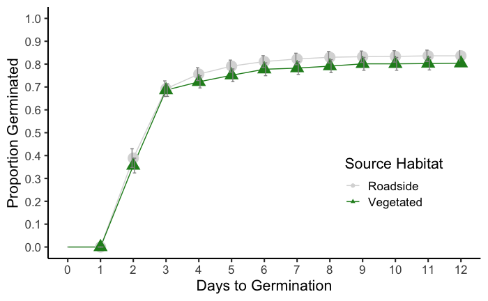

```r
#we want the graph to start at zero, but the data starts on day 2, so here we create fake data for the line to use
fakedata1<-data.frame(PlotTreatment=c("Roadside/Construction Soil","Roadside/Field Soil","Vegetated/Construction Soil","Vegetated/Field Soil"),
                      DaysToGerm=c(0),
                      DishNum=c(0),
                      PropGerm=c(0),
                      CumPropGerm=c(0),
                      type=c("fake"))

fakedata1$DaysToGerm<-as.character(fakedata1$DaysToGerm)
fakedata1$DishNum<-as.character(fakedata1$DishNum)
fakedata1$PropGerm<-as.character(fakedata1$PropGerm)
fakedata1$CumPropGerm<-as.character(fakedata1$CumPropGerm)
fakedata1$type<-as.character(fakedata1$type)

#put real data and fake data together
germ_rate1.2<-germ_rate1.1%>%
  mutate(type=c("real"))%>% #here we add a column to identify our real data
  bind_rows(fakedata1) #now we add our fake data so that we have one dataframe with real and fake data (labeled, of course)

germ_rate1.2$CumPropGerm<-as.numeric(germ_rate1.2$CumPropGerm)

germ_rate2.2<-germ_rate1.2%>%
  separate(PlotTreatment,into=c("Habitat","Treatment"),remove=FALSE,sep="/")

germ_rate2.2<-germ_rate2.2%>%
  group_by(type,DaysToGerm,Habitat)%>%
  summarize(mean_CumPropGerm=mean(CumPropGerm,
                               na.rm=TRUE),
            sd_prop=sd(CumPropGerm,na.rm=TRUE),
            se_prop=sd_prop/sqrt(40))%>%
  mutate(DaysToGerm=as.numeric(DaysToGerm))
germ_rate2.2_gg<-ggplot(germ_rate2.2, #making a graph with ggplot
                      aes(x=DaysToGerm, #variable for x-axis
                          y=mean_CumPropGerm, #variable for y-axis
                          color=Habitat, #how colors should be assigned
                          shape=Habitat))+ #how shapes should be assigned
  geom_line(linewidth=0.5)+ #now we make the line
  geom_point(aes(size=type))+ #now we add the data points
  geom_errorbar(aes(ymin=mean_CumPropGerm-se_prop,
                    ymax=mean_CumPropGerm+se_prop),
                width=0.2,
                size=0.5,
                color="gray58",
                position=position_dodge(width=0.15,))+
  theme_bw(base_size=16)+ #theme and base_size is the font size for labels
  theme(panel.border=element_blank(),
        panel.grid.major=element_blank(),
        panel.grid.minor=element_blank(),
        axis.line=element_line(colour="black"),
        legend.position = c(0.8, 0.3))+ #position of our legend
  scale_y_continuous(name="Proportion Germinated", #y-axis: title
                     limits=c(0,1), #y-axis: range
                     breaks=c(0.0,0.1,0.2,0.3,0.4,0.5,0.6,0.7,0.8,0.9,1.0))+ #y-axis: manual incremental breaks
  scale_x_continuous(name="Days to Germination", #x-axis: title
                     limits=c(0,12), #x-axis: range
                     breaks=seq(0,12,1))+ #x-axis: incremental breaks by giving range and requesting a sequence by 1
  scale_size_manual(values=c(0,5), #second number controls the size of the point
                    guide="none")+
  scale_color_manual(values=c("gray85","forestgreen"))+ #colors assigned in order of the legend
  scale_shape_manual(values=c(19,17))+
    labs(y="Proportion Germinated",
       fill="Source Habitat",
       color="Source Habitat",
       shape="Source Habitat")
germ_rate2.2_gg
```

```r
#ggsave(plot=germ_rate2.2_gg,file="/Users/Miranda/Documents/Education/UC Santa Cruz/Dittrichia/Dittrichia_Analysis/figures/germ_rate2.2_gg.png",width=25,height=15,units="cm",dpi=800)
```

##Soil Data: Proportion Germinated x Time with Treatment (data pooled by dish)

```r
mydata1<-mydata%>%
  filter(DaysToGerm!=0)%>% #our real data has some zeros because some seeds didn't germinate, but we need those to be removed since they are not real zeros
  mutate(type=c("real")) #here we add a column identifies our real

germ_rate1.0<-mydata1%>%
  group_by(DishNum,GermDate,Habitat,Treatment,DaysToGerm)%>%
  summarize(NumGerm=n(),PropGerm=NumGerm/10)%>%
  mutate(PlotTreatment=paste(Habitat,Treatment,sep="/"))%>% #create a new column called PlotTreatment combining Habitat and Treatment with a / to separate
  group_by(DishNum)%>%
  mutate(CumPropGerm=cumsum(PropGerm))
#make empty data frame to fill with closest or actual number
germ_rate1.1<-data.frame(PlotTreatment="blank",
                      DaysToGerm=c(rep(seq(1,12,1),40)),
                      DishNum=rep(seq(1,160,1),each=12),
                      PropGerm=0,CumPropGerm=0)

germ_rate1.1<-germ_rate1.1%>%
  filter(germ_rate1.1$DishNum%in%germ_rate1.0$DishNum) #actually prefilter dish numbers

#for loop to fill in missing data, may take a bit, warnings are just about making empty data frame
for (i in 1:nrow(germ_rate1.1)){
  #first check if the dish number is in the data set
  if(germ_rate1.1$DishNum[i]%in%germ_rate1.0$DishNum){
    #make temporary data frame of the data set of dish
    temp<-germ_rate1.0%>%
      filter(DishNum==germ_rate1.1$DishNum[i])%>%#first filter for the right dish
      mutate(diff=DaysToGerm-as.numeric(germ_rate1.1$DaysToGerm[i]))
    #now filter for specific day
    filltemp<-temp%>% #subtract day
      filter(diff<=0)%>% #filter for either earlier or same day
      filter(diff==max(diff))#filter for exact match or closest
    if(nrow(filltemp)>0){#check if it is empty data frame, meaning no close day
      germ_rate1.1[i,]<-c(filltemp$PlotTreatment,germ_rate1.1$DaysToGerm[i],germ_rate1.1$DishNum[i],filltemp$PropGerm,filltemp$CumPropGerm)
    }else{
    germ_rate1.1[i,]<-c(temp$PlotTreatment[1],germ_rate1.1$DaysToGerm[i],germ_rate1.1$DishNum[i],0,0)
  }}
  else{#if there is no data for the dish just skip.
    next
  }
}
```

[output not shown]

[output cut: 465 more lines]

[output not shown]

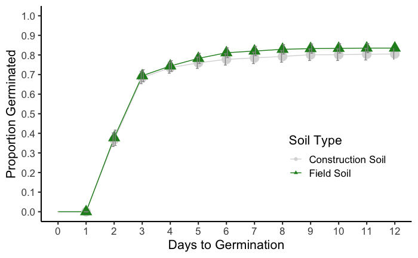

```r
#we want the graph to start at zero, but the data starts on day 2, so here we create fake data for the line to use
fakedata1<-data.frame(PlotTreatment=c("Roadside/Construction Soil","Roadside/Field Soil","Vegetated/Construction Soil","Vegetated/Field Soil"),
                      DaysToGerm=c(0),
                      DishNum=c(0),
                      PropGerm=c(0),
                      CumPropGerm=c(0),
                      type=c("fake"))

fakedata1$DaysToGerm<-as.character(fakedata1$DaysToGerm)
fakedata1$DishNum<-as.character(fakedata1$DishNum)
fakedata1$PropGerm<-as.character(fakedata1$PropGerm)
fakedata1$CumPropGerm<-as.character(fakedata1$CumPropGerm)
fakedata1$type<-as.character(fakedata1$type)

#put real data and fake data together
germ_rate1.2<-germ_rate1.1%>%
  mutate(type=c("real"))%>% #here we add a column to identify our real data
  bind_rows(fakedata1) #now we add our fake data so that we have one dataframe with real and fake data (labeled, of course)

germ_rate1.2$CumPropGerm<-as.numeric(germ_rate1.2$CumPropGerm)

germ_rate3.2<-germ_rate1.2%>%
  separate(PlotTreatment,into=c("Habitat","Treatment"),remove=FALSE,sep="/")

germ_rate3.2<-germ_rate3.2%>%
  group_by(type,DaysToGerm,Treatment)%>%
  summarize(mean_CumPropGerm=mean(CumPropGerm,
                               na.rm=TRUE),
            sd_prop=sd(CumPropGerm,na.rm=TRUE),
            se_prop=sd_prop/sqrt(40))%>%
  mutate(DaysToGerm=as.numeric(DaysToGerm))
germ_rate3.2_gg<-ggplot(germ_rate3.2, #making a graph with ggplot
                      aes(x=DaysToGerm, #variable for x-axis
                          y=mean_CumPropGerm, #variable for y-axis
                          color=Treatment, #how colors should be assigned
                          shape=Treatment))+ #how shapes should be assigned
  geom_line(linewidth=0.5)+ #now we make the line
  geom_point(aes(size=type))+ #now we add the data points
  geom_errorbar(aes(ymin=mean_CumPropGerm-se_prop,
                    ymax=mean_CumPropGerm+se_prop),
                width=0.2,
                size=0.5,
                color="gray58",
                position=position_dodge(width=0.15,))+
  theme_bw(base_size=16)+ #theme and base_size is the font size for labels
  theme(panel.border=element_blank(),
        panel.grid.major=element_blank(),
        panel.grid.minor=element_blank(),
        axis.line=element_line(colour="black"),
        legend.position = c(0.8, 0.3))+ #position of our legend
  scale_y_continuous(name="Proportion Germinated", #y-axis: title
                     limits=c(0,1), #y-axis: range
                     breaks=c(0.0,0.1,0.2,0.3,0.4,0.5,0.6,0.7,0.8,0.9,1.0))+ #y-axis: manual incremental breaks
  scale_x_continuous(name="Days to Germination", #x-axis: title
                     limits=c(0,12), #x-axis: range
                     breaks=seq(0,12,1))+ #x-axis: incremental breaks by giving range and requesting a sequence by 1
  scale_size_manual(values=c(0,5), #second number controls the size of the point
                    guide="none")+
  scale_color_manual(values=c("gray85","forestgreen"))+ #colors assigned in order of the legend
  scale_shape_manual(values=c(19,17))+
    labs(y="Proportion Germinated",
       fill="Soil Type",
       color="Soil Type",
       shape="Soil Type")
germ_rate3.2_gg
```

```r
#ggsave(plot=germ_rate3.2_gg,file="/Users/Miranda/Documents/Education/UC Santa Cruz/Dittrichia/Dittrichia_Analysis/figures/germ_rate3.2_gg.png",width=25,height=15,units="cm",dpi=800)
```